# DATASCI 530 Assignment 4

# Bills Actions from the 116th Congress of the United States

Maxine Hakimi-Bulson

## Summary of Findings

The bills actions dataset from the 116th Congress of the United States reveals patterns in Congress that are not clear from directly exploring the original text in the dataset. Almost half of the actions committed from the 116th Congress were amendments. Most house floor actions involving Senate bills included suspension of the rules. Most bills in the Senate amendment subset mention two distinct senators, and McConnell and Reed appear with the greatest number of different senators in the action descriptions. House members Brown, Rouda, and Gosar offered amendments more often than other members.

## Loading Libraries and Data

First we will load the necessary libraries and data to complete our analyses.

```python
import pandas as pd
import matplotlib.pyplot as plt
import numpy as np

bills_actions = pd.read_csv("data/bills_actions.csv")
```

## Inquiry & Analysis

### Basic Descriptive Statistics

- How many distinct “bill” identifiers are there?
- What proportion of rows belongs to each category?
- What proportion belongs to different “main_action”?

I counted distinct combinations of bill type and bill number to account for different bill types sharing the same number. While Data Wrangler provides summary statistics, the category summaries only display the top 3 values and percentages, and the rest are listed as "Other." This is an issue since `main_action` lists 31% of its data under "Other," so I calculated the counts and proportions for every category.

```python
# count distinct bill identifiers
identifier_counts = bills_actions.groupby(
    ["bill_type", "bill_number"]).size()
number_identifiers = len(identifier_counts)
#print(number_identifiers)

# counts and proportions of all action rows
table_category = pd.DataFrame({
    "Number of rows": bills_actions["category"].value_counts()})
table_category["Proportion"] = (table_category["Number of rows"] / len(bills_actions))

# main action counts and proportions of all action rows
table_main_action = pd.DataFrame({
    "Number of rows": bills_actions["main_action"].value_counts()})
table_main_action["Proportion"] = (table_main_action["Number of rows"] / len(bills_actions))

# display results side by side
from IPython.display import display, HTML

category_html = (
    table_category.style
    .format({
        "Number of rows": "{:,.0f}",
        "Proportion": "{:.1%}"
    })
    .set_caption("Action rows by category")
    .to_html())

main_action_html = (
    table_main_action.style
    .format({
        "Number of rows": "{:,.0f}",
        "Proportion": "{:.1%}"
    })
    .set_caption("Action rows by main action")
    .to_html())

display(HTML(
    '<div style="display:flex; gap:30px; align-items:flex-start;">'
    '<div>' + category_html + '</div>'
    '<div>' + main_action_html + '</div>'
    '</div>'))

# quality checks: both proportions should sum to approximately 1
#print(table_category["Proportion"].sum())
#print(table_main_action["Proportion"].sum())
```

Action rows by category

| category | Number of rows | Proportion |
| --- | --- | --- |
| amendment | 1,529 | 46.3% |
| house bill | 902 | 27.3% |
| senate bill | 514 | 15.6% |
| house resolution | 234 | 7.1% |
| senate resolution | 60 | 1.8% |
| house joint resolution | 22 | 0.7% |
| house concurrent resolution | 20 | 0.6% |
| senate concurrent resolution | 14 | 0.4% |
| senate joint resolution | 8 | 0.2% |

Action rows by main action

| main_action | Number of rows | Proportion |
| --- | --- | --- |
| house floor actions | 1,020 | 30.9% |
| house amendment offered | 828 | 25.1% |
| senate committee/subcommittee actions | 434 | 13.1% |
| other house amendment actions | 397 | 12.0% |
| senate amendment proposed (on the floor) | 286 | 8.7% |
| house committee/subcommittee actions | 218 | 6.6% |
| reported to senate | 36 | 1.1% |
| senate committee report filed after reporting | 33 | 1.0% |
| other senate amendment actions | 18 | 0.5% |
| resolving differences -- house actions | 14 | 0.4% |
| senate floor actions | 13 | 0.4% |
| house discharge petition filed | 3 | 0.1% |
| resolving differences -- senate actions | 3 | 0.1% |

There are 1,494 distinct bill identifiers. Amendments account for almost half of the action rows (46.3%), followed by House (27.3%) and Senate bills (15.6%). House floor actions (30.9%) and House amendments offered (25.1%) are the most common main actions, together representing over half of the rows.

### House Floor Actions Associated with Bills in the “Senate bills” Category

- What proportion of these actions were suspended? What proportion of these actions were suspended as amended?
- The House floor actions mention specific people by (Mr., Ms., Mrs., etc). Use regular expressions to extract the names of specific people. Produce a new dataset counting how many bills mention the same person and then extract the unique list of names of the people mentioned. What is the distribution of total bills proposed per person?

I filtered the dataset to House floor actions in the Senate bill category and counted the rows to find the number of house floor actions associated with bills in the "Senate bills" category. Then, I searched the action text for “suspend the rules” and “as amended,” and calculated the proportions of each. Next, I use a regular expression to extract names following “Mr.,” “Ms.,” or “Mrs.” and ending before “asked” or “moved,” in case their full name or if their state is also listed. I grouped the names with bill type and bill number to count each distinct bill only once per person, got the unique names, and plotted the bill counts for the top 10 people mentioned in a bar chart.

Suspension mentions in House floor actions on Senate bills

| Action description | Number of actions | Proportion |
| --- | --- | --- |
| Mentions suspension of the rules | 80 | 69.0% |
| Mentions suspension and passage as amended | 18 | 15.5% |

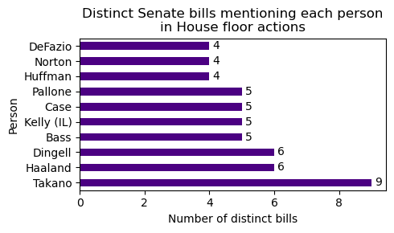

```python
# select house floor actions associated with Senate bills
senate_bills_house_floor = bills_actions.query(
    'category == "senate bill" & main_action == "house floor actions"')
number_actions = len(senate_bills_house_floor)
#print(number_actions)

# identify suspension mentions, including those specifying "as amended"
suspension = senate_bills_house_floor["action"].str.contains("suspend the rules")
suspension_amended = (suspension & senate_bills_house_floor["action"].str.contains("as amended"))

table_suspension = pd.DataFrame({
    "Action description": [
        "Mentions suspension of the rules",
        "Mentions suspension and passage as amended"],
    "Number of actions": [suspension.sum(), suspension_amended.sum()],
    "Proportion": [suspension.mean(), suspension_amended.mean()]})

display(
    table_suspension.style
    .format({
        "Number of actions": "{:,.0f}",
        "Proportion": "{:.1%}"
    })
    .hide(axis="index")
    .set_caption("Suspension mentions in House floor actions on Senate bills"))

# extract names and attach them to bill identifiers
name_matches = senate_bills_house_floor["action"].str.findall(
    r"(?:Mr|Ms|Mrs)\. (.*?) (?:asked|moved)")

people_bills = senate_bills_house_floor[
    ["bill_type", "bill_number"]].copy()
people_bills["Person"] = name_matches.apply(lambda names: names[0])

# count each distinct bill once per person
person_bill_counts = (
    people_bills.groupby(["Person", "bill_type", "bill_number"])
    .size()
    .reset_index(name="Number of actions"))

table_people = (
    person_bill_counts.groupby("Person")
    .size()
    .reset_index(name="Number of distinct bills"))

unique_people = table_people["Person"].unique()

# plot bill counts for all people
people_plot = table_people.sort_values(
    "Number of distinct bills", ascending=False)

pp = people_plot.head(10).plot(
    x="Person",
    y="Number of distinct bills",
    kind="barh",
    color="indigo",
    figsize=(5, 3),
    legend=False)
pp.bar_label(pp.containers[0], padding=3)
plt.xlabel("Number of distinct bills")
plt.ylabel("Person")
plt.title("Distinct Senate bills mentioning each person\nin House floor actions")
plt.tight_layout()
plt.show()

# quality checks
#print(name_matches.apply(len).value_counts())
#print(len(unique_people))
#print(unique_people)
```

There are 116 house floor actions associated with Senate bills. 69% (80) of those mention a motion to suspend the rules, and 15.5% (18) motion to suspend as amended. Takano, Haaland, and Dingell are mentioned in the most amount of bills.

### Senate Amendment Proposed Bills

- Produce a new dataset counting how many senators are mentioned per bill. This dataset should also include two variables, with the name of the first senator (Senator 1) mentioned in the bill and the name of the second senator (Senator 2). What is the distribution of the number of senators per bill?
- With how many different people does each Senator coauthor bills, i.e. how many different people appear as Senator 2 for each Senator 1?

I selected actions marked “senate amendment proposed (on the floor)” and used regular expressions to extract senator names. I grouped the actions by bill type number and counted each different senator name one time per bill. I recorded the first two names mentioned. I displayed a preview of this dataset to see which senators work with each other. I also displayed a table of the distribution of senator counts per bill. I counted the different Senator 2 names appearing with each Senator 1 name, and I plotted the top ten most mentioned Senator 1 names in a bar chart.

Senator counts and names for eight bills

| Number of senators | Senator 1 | Senator 2 |
| --- | --- | --- |
| 2 | McConnell | Shelby |
| 2 | McConnell | Shelby |
| 2 | Moran | Rubio |
| 2 | McConnell | Johnson |
| 1 | McConnell | Not mentioned |
| 3 | McConnell | Shelby |
| 2 | McConnell | Murkowski |
| 2 | Sasse | McConnell |

Senator count per bill

| Number of senators | Number of bills |
| --- | --- |
| 1 | 21 |
| 2 | 99 |
| 3 | 4 |
| 4 | 3 |
| 5 | 1 |
| 7 | 1 |
| 30 | 1 |
| 38 | 1 |

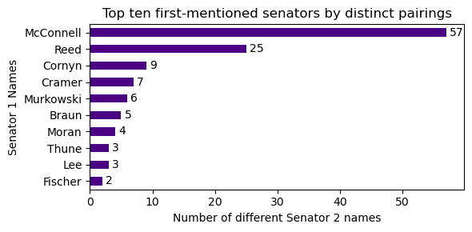

```python
# select senate amendments proposed on the floor
senate_amendments = bills_actions.query(
    'main_action == "senate amendment proposed (on the floor)"').copy()

# extract senator names
senate_amendments["Senator names"] = (
    senate_amendments["action"].str.findall(
        r"Senator ([A-Z][A-Za-z'-]*(?: [A-Z][A-Za-z'-]*)*)"))

# combine each bill's actions and only count each senator once
def unique_senators(name_lists):
    names = []
    for name_list in name_lists:
        for name in name_list:
            if name not in names:
                names.append(name)
    return names

senators_per_bill = (
    senate_amendments.groupby(
        ["bill_type", "bill_number"]
    )["Senator names"]
    .agg(unique_senators)
    .reset_index())

senators_per_bill["Number of senators"] = (
    senators_per_bill["Senator names"].apply(len))

for position, column in enumerate(["Senator 1", "Senator 2"]):
    senators_per_bill[column] = senators_per_bill["Senator names"].apply(
        lambda names: names[position] if len(names) > position else None)

# preview eight bills
preview_html = (
    senators_per_bill[
        ["Number of senators",
         "Senator 1", "Senator 2"]
    ].head(8).style
    .format(na_rep="Not mentioned")
    .hide(axis="index")
    .set_caption("Senator counts and names for eight bills")
    .to_html())

# distribution of distinct senators per bill
table_distribution = (
    senators_per_bill.groupby("Number of senators")
    .size()
    .reset_index(name="Number of bills"))

distribution_html = (
    table_distribution.style
    .hide(axis="index")
    .set_caption("Senator count per bill")
    .to_html())

# display both tables side by side
display(HTML(
    '<div style="display:flex; gap:30px; align-items:flex-start;">'
    '<div>' + preview_html + '</div>'
    '<div>' + distribution_html + '</div>'
    '</div>'))

# part 2: extract pairings within each individual action
senate_amendments["Senator 1"] = (
    senate_amendments["Senator names"].apply(
        lambda names: names[0] if names else None))
senate_amendments["Senator 2"] = (
    senate_amendments["Senator names"].apply(
        lambda names: names[1] if len(names) > 1 else None))

# count different second-mentioned senators; missing names count as zero
table_partners = (
    senate_amendments.groupby("Senator 1")["Senator 2"]
    .nunique()
    .reset_index(name="Different Senator 2 names")
    .sort_values(
        ["Different Senator 2 names", "Senator 1"],
        ascending=[False, True]))

# part 3: plot the top ten, with exact counts beside the bars (senator 1's with the most senator 2's)
partners_plot = table_partners.head(10).sort_values(
    "Different Senator 2 names", ascending=True)

ax = partners_plot.plot(
    x="Senator 1",
    y="Different Senator 2 names",
    kind="barh",
    color="indigo",
    figsize=(6, 3),
    legend=False)
ax.bar_label(ax.containers[0], padding=3)

plt.xlabel("Number of different Senator 2 names")
plt.ylabel("Senator 1 Names")
plt.title("Top ten first-mentioned senators by distinct pairings")
plt.tight_layout()
plt.show()

# quality checks: ensure there are 131 bills
#print(len(senators_per_bill))
#print(table_distribution["Number of bills"].sum())
```

The first table reveals McConnell works with Shelby a lot. Of the 131 bills we are exploring, 99 of these senate amendment proposed bills involve two senators, and 21 bills involve only one senator. It is surprising to see there are two bills involving 30 or more senators. The bar chart shows McConnell has worked with 57 different senator 2's, which is much more than the other senators. Reed worked with 25 distinct senators, and Cornyn worked with 9.

### Insights

Amendments made up approximately half of the action records. House floor actions and House amendments offered were the most common action types. Most House floor actions regarding Senate bills involved suspension of the rules. Takano, Dingell, and Haaland appeared in the most distinct bills. Most bills with Senate amendments proposed on the floor mentioned two distinct senators, and two bills mentioned 30 or more senators across their selected actions. McConnell had the most second senators mentioned, followed by Reed and Cornyn. These results show the few senators who dominate the bills with Senate amendments proposed on the floor.

## New Insight

### Which members of the 116th Congress offered the most House amendments?

I selected actions marked “house amendment offered” and used regular expressions to extract each member’s name and their amendment number and created a word cloud using these counts.

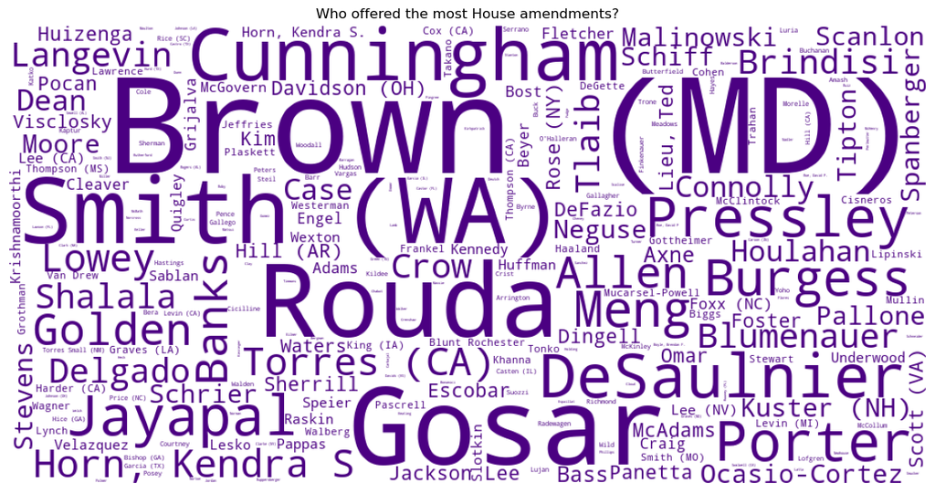

```python
# select house amendments offered
house_amendments = bills_actions.query(
    'main_action == "house amendment offered"').copy()

# extract member names and House amendment numbers
member_matches = house_amendments["action"].str.findall(
    r"offered by (?:Mr|Ms|Mrs)\. (.*?)(?=\. \(|\.$)")
amendment_matches = house_amendments["action"].str.findall(
    r"H\.Amdt\.(\d+)")

# quality checks: one member and amendment number for each row
#print(member_matches.apply(len).value_counts())
#print(amendment_matches.apply(len).value_counts())

house_amendments["Member"] = member_matches.apply(
    lambda names: names[0])
house_amendments["Amendment number"] = amendment_matches.apply(
    lambda numbers: numbers[0])

# word cloud:
from wordcloud import WordCloud

# count amendments offered by each member
table_house_members = (
    house_amendments.groupby("Member")
    .size()
    .reset_index(name="Number of amendments offered")
    .sort_values(
        ["Number of amendments offered", "Member"],
        ascending=[False, True]))
# use the amendment counts as the weight for each member's name
member_frequencies = (
    table_house_members.set_index("Member")["Number of amendments offered"]
    .to_dict())

word_cloud = WordCloud(
    width=1000,
    height=500,
    background_color="white",
    color_func=lambda *args, **kwargs: "indigo",
    relative_scaling=1,
    max_words=len(member_frequencies),
    random_state=42
).generate_from_frequencies(member_frequencies)

plt.figure(figsize=(12, 6))
plt.imshow(word_cloud)
plt.axis("off")
plt.title("Who offered the most House amendments?")
plt.tight_layout()
plt.show()
```

### What we learn from this WordCloud

In a world cloud, the larger member names offered more house amendments. We discover Brown (MD), SMith (WA), Rouda, Gosar, and Cunningham offer the most house amendments.